# How to build an image classification model with the high-level API

Insights from ["Deep Learning for Coders with fastai & PyTorch"](https://github.com/fastai/fastbook) and from around the world

Jan 21, 2022 • Wayde Gilliam • 8 min read

fastai fastbook fastbook chapter 2 how to train image multiclass classification

- Step 1: Get your data
- Step 2: Build your DataBlock
- Step 3: Train your model
- Step 4: Inference
- Resources for training/deploying image classification models

In this post we go over a basic, high-level, example on training a multiclassification computer vision model that is inspired by the example presented in chapter 2.

## Step 1: Get your data

We can grab all kinda of useful datasets via the [fast.ai Datasets](https://course.fast.ai/datasets) for various tasks and data types (e.g., images, text, etc...). In this example we'll work with the `Imagnette` dataset, a "subset of 10 easily classified classes from Imagenet."

**Tip:** Working with a representative subset of your full dataset is recommended for experimentation and as a means to verify your data prep and model training.

```python
import PIL

from fastai.data.all import *
```

We'll use `untar_data` to both download and decompress the dataset. It will return a `Pathlib` object pointing to where the data has been downloaded

```python
raw_data_path = untar_data(URLs.IMAGENETTE)
print(raw_data_path)
raw_data_path.ls()
```

100.00% [1557168128/1557161267 00:58<00:00]

```
/root/.fastai/data/imagenette2
```

```
(#3) [Path('/root/.fastai/data/imagenette2/train'),Path('/root/.fastai/data/imagenette2/val'),Path('/root/.fastai/data/imagenette2/noisy_imagenette.csv')]
```

We can use `get_image_files()` to grab all the image filepaths in the training set. This method takes a path as an argument and recursively grabs all the images in that path by default.

We'll need to know how to infer the class for each image and this can be done by looking at one or more of the actual image filepaths.

```python
files = get_image_files(raw_data_path/'train')
```

```python
files[0]
```

```
Path('/root/.fastai/data/imagenette2/train/n03425413/n03425413_16975.JPEG')
```

Here we can see that the convention followed for this dataset is having the class Id we want to predict in its parent folder, while each image's unique name is the class_id followed by a unique identifier: `{class_id}/{class_id}_{unique_id}.JPEG`.

We can validate this by ensure we see 10 parent folders ...

```python
(raw_data_path/'train').ls()
```

```
(#10) [Path('/root/.fastai/data/imagenette2/train/n03425413'),Path('/root/.fastai/data/imagenette2/train/n03417042'),Path('/root/.fastai/data/imagenette2/train/n03000684'),Path('/root/.fastai/data/imagenette2/train/n03394916'),Path('/root/.fastai/data/imagenette2/train/n03445777'),Path('/root/.fasta…
```

We can even look at one or more of the images using the `PIL` package

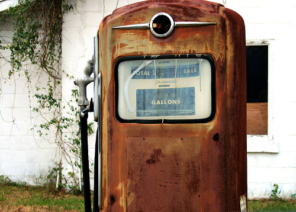

```python
img = PIL.Image.open(files[0])
img
```

## Step 2: Build your `DataBlock`

The objective here is to ultimately be able to build `DataLoaders` you can feed into your model. There are a variety of ways to do this but the recommended go to is to use the mid-level `DataBlock API` if you can. A `DataBlock` represents a blueprint for building `DataLoaders` from your raw data, whereas the `DataLoaders` are what allow us to feed our examples into our model a mini-batch (a few) at a time.

```python
from fastai.vision.all import *
```

```python
dblock = DataBlock(
    blocks=(ImageBlock, CategoryBlock),              # tell the block what are INPUTS/TARGETS are (images and a category/class here)
    get_items=get_image_files,                       # tell the block HOW TO GET THE DATA (here its files but could also be rows in a .csv, etc...)
    splitter=RandomSplitter(valid_pct=0.2, seed=42), # tell the block HOW TO BUILD THE VALIDATION SET (here we just randomly select 20% data)
    get_y=parent_label,                              # tell the block WHERE TO GET OUR LABELS (here from the parent folder)
    item_tfms=Resize(128))                           # tell the block things WE WANT DONE EACH TIME WE GRAB AN ITEM from the dataset
```

If you're unsure what any of these classes or methods do, don't forget about the `??` syntax you can use in notebooks. For example ...

```python
ImageBlock??
```

**Note:** We specify `Resize(128)` as an **item transform** because ultimately we’ll feed the data into our model a *mini-batch* at a time, and in order to take advantage of the GPU and tensor operations that items we feed in need to be the same size.

"*Item transforms* are pieces of code that run on each individual item, whether it be an image, category, or so forth." <sup>1</sup>

```python
dls = dblock.dataloaders(raw_data_path)
```

We *implement* our blueprint by passing the path to the image files into the `DataBlock.dataloaders()` method. Whatever we pass in as an argument here, gets passed to the function we specified in `get_items` above (which is`get_image_files` in this case). While iterating over each image, `get_y` will be used to grab the label of the image and our two blocks, `ImageBlock` and `CategoryBlock` will provide both the pre and post-processing necessary to work with our images and classes. Finally, our `splitter` will randomly take 20% of the dataset and set it aside for our validation set.

**Tip:** You want to ensure you get the same validation set each time so you can meaningfully assess the performance of your model(s) as you tweak things. You do this by assigning a `seed`. If you don’t do this, you won’t know if your model’s performance is due to it seeing different images in the validation set or because of change you’ve made in your hyperparameters, model architecture, etc...

Each time we grab an image, regardless of the size, from the dataset, we resize it as a 128x128 tensor.

[figure not shown]

```python
dls.show_batch(max_n=4, nrows=1)
```

By default, this method crops the images to fit a square (but as you can see here we can also have fastai pad the images with zeroes, squish, or stretch them.).

```python
dblock2 = dblock.new(item_tfms=RandomResizedCrop(128, min_scale=0.2))
dls = dblock2.dataloaders(raw_data_path)
```

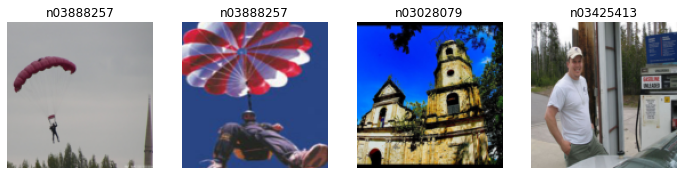

```python
dls.valid.show_batch(max_n=4, nrows=1)
```

**Tip:** When dealing with data augmentation, its often helpful to see how a *single* example is augmented.

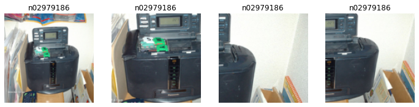

```python
dls.train.show_batch(max_n=4, nrows=1, unique=True)
```

Using `RandomResizedCrop` allows " our model can learn to focus on, and recognize, different features in our images. It also reflects how images work in the real world: different photos of the same thing may be framed in slightly different ways." <sup>2</sup>

**Tip:** "...training the neural network with examples of images where the objects are in slightly different places and slightly different sizes helps it to understand the basic concept of what an object is, and how it can be represented in an image."

<sup>3</sup>

We can, and should, also use **data augmentation** to create "random variations" that are representative of what our model will see in the wild. "Examples of common data augmentation techniques for images are rotation, flipping, perspective warping, brightness changes and contrast changes." <sup>4</sup>

For "natural photos", fastai provides the `aug_tranforms()` method that have proven to work well in general.

In addition, such "data augmentations" are tyically desirable to have run on the GPU since they'll run much faster. To make this happen, these "transforms" are specified as `batch_tfms` since them happen on a "mini-batch" at a time.

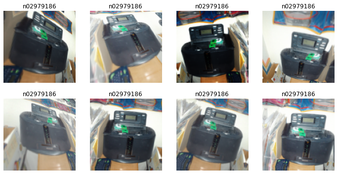

```python
dblock2 = dblock.new(item_tfms=Resize(128), batch_tfms=aug_transforms(mult=2))
dls = dblock2.dataloaders(raw_data_path)
dls.train.show_batch(max_n=8, nrows=2, unique=True)
```

Using the `unique=True` argument with our `DataLoaders.show_batch()` method allows us to see how these augmentations are applied to a single image.

**Tip:** Verify that the augmentations you use are representative of what your model will see in the wild

**Tip:** Use augmentations to artificially provide more images than you do in your raw dataset

## Step 3: Train your model

```python
dblock = dblock.new(
    item_tfms=RandomResizedCrop(224, min_scale=0.5),
    batch_tfms=aug_transforms())

dls = dblock.dataloaders(raw_data_path)
```

```python
learn = cnn_learner(dls, resnet18, metrics=error_rate)
learn.fine_tune(4)
```

```
Downloading: "https://download.pytorch.org/models/resnet18-f37072fd.pth" to /root/.cache/torch/hub/checkpoints/resnet18-f37072fd.pth
```

| epoch | train_loss | valid_loss | error_rate | time |
| --- | --- | --- | --- | --- |
| 0 | 0.221943 | 0.052735 | 0.014937 | 01:41 |

| epoch | train_loss | valid_loss | error_rate | time |
| --- | --- | --- | --- | --- |
| 0 | 0.116465 | 0.081874 | 0.021285 | 01:43 |
| 1 | 0.120003 | 0.067953 | 0.019044 | 01:43 |
| 2 | 0.062349 | 0.058985 | 0.017550 | 01:44 |
| 3 | 0.046365 | 0.047561 | 0.014563 | 01:42 |

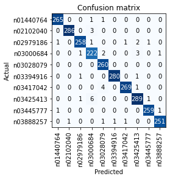

```python
interp = ClassificationInterpretation.from_learner(learn)
interp.plot_confusion_matrix()
```

**Tip:** "It’s helpful to see where exactly our errors are occurring, to see whether they’re due to a dataset problem (e.g., images that aren’t bears at all, or are labeled incorrectly, etc.), or a model problem (perhaps it isn’t handling images taken with unusual lighting, or from a different angle, etc.). To do this, we can sort our images by their loss."

<sup>5</sup>

For each image shown, `ClassificationInterpretation.plot_top_losses()` shows four things: the predicted class, the actual class, the loss, and the probability

[figure not shown]

```python
interp.plot_top_losses(5, nrows=1)
```

**Tip:** " a model can actually help you find data issues more quickly and easily. So, we normally prefer to train a quick and simple model first, and then use it to help us with data cleaning."

<sup>6</sup>

fastai includes the `ImageClassifierCleaner` that can be used to "clean your dataset" (remove or re-label images). See chapter 2 for more information on how to use this utility.

## Step 4: Inference

"Remember that a model consists of two parts: the architecture and the trained parameters. The easiest way to save the model is to save both of these, because that way when you load a model you can be sure that you have the matching architecture and parameters." <sup>7</sup>

How do we do this? We use `Learner.export()`.

By using this method we don't have to redefine how the data needs to be transformed as the inference learner will know what transforms to apply based on what was applied to your validation `DataLoader`. For example, it will know *not* to apply any data augmentation which is only really useful during training.

```python
learn.export()

path = Path()
path.ls(file_exts='.pkl')
```

```
(#1) [Path('export.pkl')]
```

```python
learn_inf = load_learner(path/'export.pkl')
learn_inf.dls.vocab
```

```
['n01440764', 'n02102040', 'n02979186', 'n03000684', 'n03028079', 'n03394916', 'n03417042', 'n03425413', 'n03445777', 'n03888257']
```

Calling `Learner.predict()` will return the predicated label, the label index in the vocab, and the probabilities assigned to each of our 10 labels.

```python
learn_inf.predict(files[0])
```

```
('n03425413',
 TensorBase(7),
 TensorBase([1.2492e-08, 1.0755e-08, 5.4347e-06, 1.3099e-09, 5.8689e-08, 2.4089e-09,
         2.4208e-07, 9.9999e-01, 4.2802e-09, 1.9702e-09]))
```

## Resources for training/deploying image classification models

See chapter 2 for more information on options to consider when training and deploying image classification models

1. "Chaper 2: From Model to Production". In *[The Fastbook](https://www.amazon.com/Deep-Learning-Coders-fastai-PyTorch/dp/1492045527)* p.71

2. Ibid.,p.73

3. Ibid.,p.73

4. Ibid.,p.74

5. Ibid.,p.76

6. Ibid.,pp.77-78 walks you through using the ImageClassifierCleaner for those interested in using it to fix your own computer vision datasets

7. Ibid.,p.78